# Project

## *Exploratory Data Analysis:*

```r
summary(data)
```

```
##     brand              model           processor_brand    processor_name
##  Length:896         Length:896         Length:896         Length:896
##  Class :character   Class :character   Class :character   Class :character
##  Mode  :character   Mode  :character   Mode  :character   Mode  :character
##
##
##
##  processor_gnrtn        ram_gb         ram_type              ssd
##  Length:896         Min.   : 4.000   Length:896         Min.   :   0.0
##  Class :character   1st Qu.: 4.000   Class :character   1st Qu.: 256.0
##  Mode  :character   Median : 8.000   Mode  :character   Median : 512.0
##                     Mean   : 8.531                      Mean   : 432.3
##                     3rd Qu.: 8.000                      3rd Qu.: 512.0
##                     Max.   :32.000                      Max.   :3072.0
##       hdd              os                os_bit      graphic_card_gb
##  Min.   :   0.0   Length:896         Min.   :32.00   Min.   :0.000
##  1st Qu.:   0.0   Class :character   1st Qu.:64.00   1st Qu.:0.000
##  Median :   0.0   Mode  :character   Median :64.00   Median :0.000
##  Mean   : 226.9                      Mean   :59.18   Mean   :1.199
##  3rd Qu.: 512.0                      3rd Qu.:64.00   3rd Qu.:2.000
##  Max.   :2048.0                      Max.   :64.00   Max.   :8.000
##     weight           display_size     warranty     Touchscreen
##  Length:896         Min.   :12.2   Min.   :0.000   Length:896
##  Class :character   1st Qu.:15.6   1st Qu.:0.000   Class :character
##  Mode  :character   Median :15.6   Median :1.000   Mode  :character
##                     Mean   :15.3   Mean   :0.692
##                     3rd Qu.:15.6   3rd Qu.:1.000
##                     Max.   :17.3   Max.   :3.000
##    msoffice          latest_price     star_rating      ratings
##  Length:896         Min.   : 13990   Min.   :0.00   Min.   :    0.0
##  Class :character   1st Qu.: 45490   1st Qu.:0.00   1st Qu.:    0.0
##  Mode  :character   Median : 63494   Median :4.10   Median :   19.0
##                     Mean   : 76310   Mean   :2.98   Mean   :  367.4
##                     3rd Qu.: 89090   3rd Qu.:4.40   3rd Qu.:  179.5
##                     Max.   :441990   Max.   :5.00   Max.   :15279.0
##     reviews
##  Min.   :   0.00
##  1st Qu.:   0.00
##  Median :   3.00
##  Mean   :  46.15
##  3rd Qu.:  23.25
##  Max.   :1947.00
```

```r
nrow(data)
```

```
## [1] 896
```

```r
ncol(data)
```

```
## [1] 21
```

```r
numeric_columns <- sapply(data, is.numeric)

# Print the results
print(numeric_columns)
```

```
##           brand           model processor_brand  processor_name processor_gnrtn
##           FALSE           FALSE           FALSE           FALSE           FALSE
##          ram_gb        ram_type             ssd             hdd              os
##            TRUE           FALSE            TRUE            TRUE           FALSE
##          os_bit graphic_card_gb          weight    display_size        warranty
##            TRUE            TRUE           FALSE            TRUE            TRUE
##     Touchscreen        msoffice    latest_price     star_rating         ratings
##           FALSE           FALSE            TRUE            TRUE            TRUE
##         reviews
##            TRUE
```

```r
print(sum(numeric_columns))
```

```
## [1] 11
```

```r
print(sum(is.na(data)))
```

```
## [1] 0
```

```r
print(sum(duplicated(data)))
```

```
## [1] 21
```

```r
data <- unique(data)
```

Count number of models by brand

```r
table(data$brand)
```

```
##
##      acer ALIENWARE     APPLE      ASUS     Avita      DELL        HP     iball
##        58         4        23       249        10       153       142         1
##   Infinix    Lenovo        LG        Mi MICROSOFT       MSI     Nokia    realme
##         3       151         4         2         3        52         4         4
## RedmiBook   SAMSUNG  Smartron      Vaio
##         3         1         3         5
```

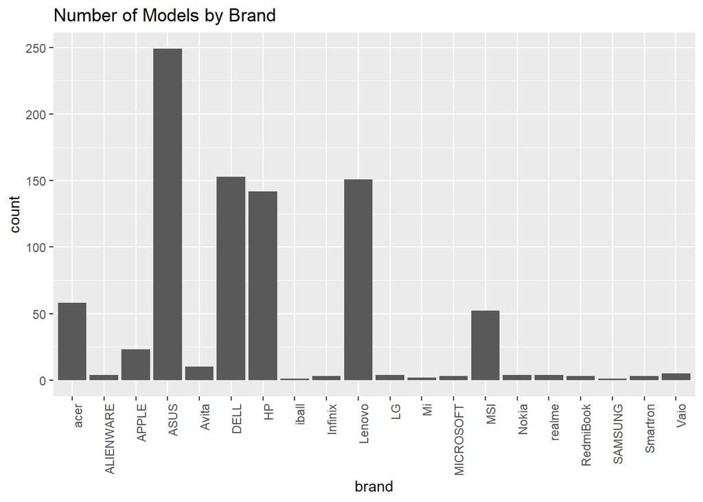

```r
ggplot(data = data, aes(x = brand)) +
  geom_bar() +
  theme(axis.text.x = element_text(angle = 90, hjust = 1)) +
  labs(title="Number of Models by Brand")
```

Top 5 brands

```r
names(sort(table(data$brand), decreasing = TRUE)[1:5])
```

```
## [1] "ASUS"   "DELL"   "Lenovo" "HP"     "acer"
```

Count processors

```r
table(data$processor_name)
```

```
##
## A6-9225 Processor          APU Dual       Athlon Dual      Celeron Dual
##                 1                 7                 2                23
##              Core           Core i3           Core i5           Core i7
##                 1               166               306               107
##           Core i9           Core m3         Dual Core    Ever Screenpad
##                 8                 1                 3                 2
##       GeForce GTX       GeForce RTX       GEFORCE RTX   Genuine Windows
##                 2                 4                 1                 3
##         Hexa Core                M1 MediaTek Kompanio      Pentium Quad
##                 2                19                 3                14
##    Pentium Silver              Quad             Ryzen           Ryzen 3
##                 2                 1                 1                26
##           Ryzen 5           Ryzen 7           Ryzen 9     Snapdragon 7c
##                85                58                26                 1
```

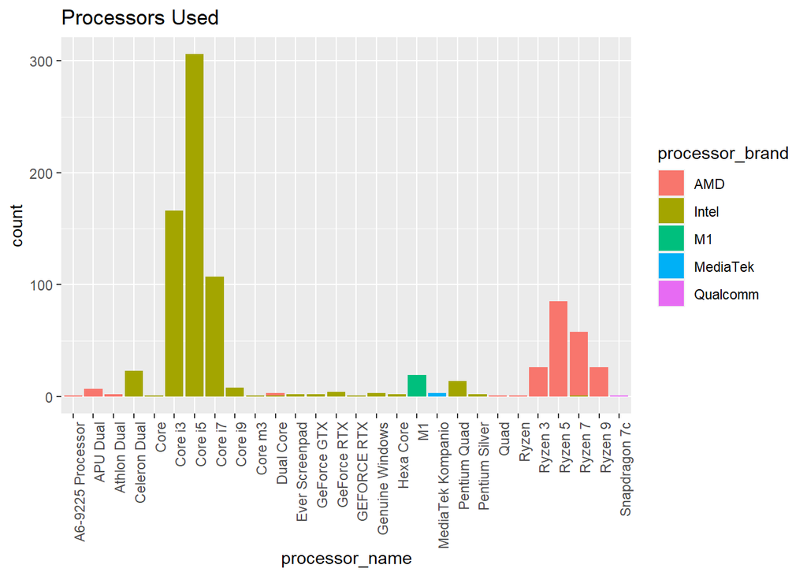

```r
ggplot(data = data, aes(x = processor_name, fill = processor_brand)) +
  geom_bar() +
  theme(axis.text.x = element_text(angle = 90, hjust = 1)) +
  labs(title="Processors Used")
```

Most common processors

```r
names(sort(table(data$processor_name), decreasing = TRUE)[1:10])
```

```
##  [1] "Core i5"      "Core i3"      "Core i7"      "Ryzen 5"      "Ryzen 7"
##  [6] "Ryzen 3"      "Ryzen 9"      "Celeron Dual" "M1"           "Pentium Quad"
```

Count operating systems

```r
table(data$os)
```

```
##
##     DOS     Mac Windows
##      36      23     816
```

Count RAM capacities

```r
table(data$ram_gb)
```

```
##
##   4   8  16  32
## 256 439 177   3
```

Count storage types

```r
table(data$ssd, data$hdd)
```

```
##
##          0 512 1024 2048
##   0      0  62   87    1
##   32     1   0    0    0
##   128   11   0    1    0
##   256  117   0   72    0
##   512  405   2    3    0
##   1024 110   0    0    0
##   2048   2   0    0    0
##   3072   1   0    0    0
```

Models with dedicated GPUs

```r
nrow(subset(data, graphic_card_gb > 0))
```

```
## [1] 265
```

Most common display sizes

```r
table(data$display_size)
```

```
##
##  12.2    13  13.3  13.4    14  14.1  14.2  14.9 14.96    15  15.6    16  16.1
##     2     4    34     1   123     6     2     1     7     3   544   135     1
##  16.2  17.3
##     3     9
```

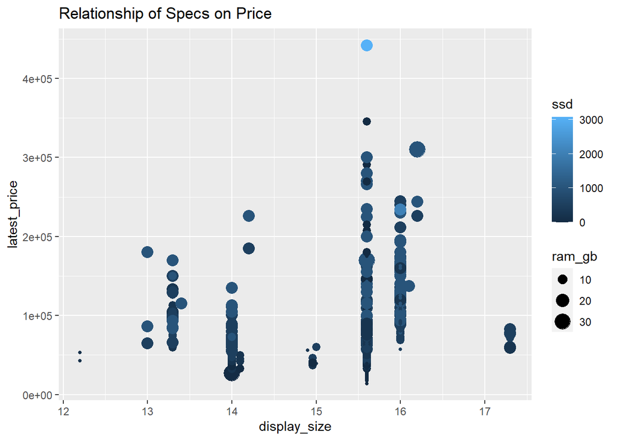

```r
ggplot(data = data,
       mapping = aes(x = display_size, y = latest_price,
                     size = ram_gb, color = ssd)) +
  geom_point() +
  labs(title = "Relationship of Specs on Price")
```

Models with touch screens

```r
nrow(subset(data, Touchscreen == "Yes"))
```

```
## [1] 102
```

Weight categories

```r
table(ifelse(data$weight == "ThinNlight", "Thin", ifelse(data$weight == "Casual", "Regular", ifelse(data$weight == "Gaming", "Gaming", NA))))
```

```
##
##  Gaming Regular    Thin
##      39     556     280
```

Summary statistics of price

```r
summary(data$latest_price)
```

```
##    Min. 1st Qu.  Median    Mean 3rd Qu.    Max.
##   13990   45240   62990   76276   89190  441990
```

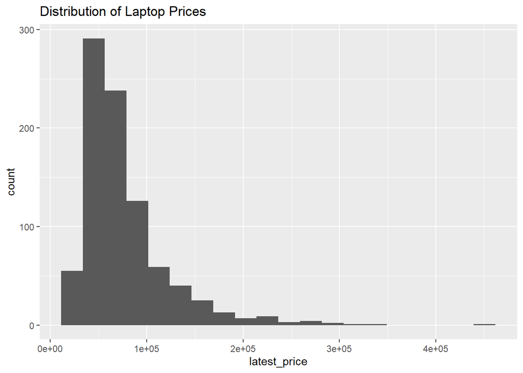

```r
ggplot(data, aes(latest_price)) +
  geom_histogram(bins=20) +
  labs(title = "Distribution of Laptop Prices")
```

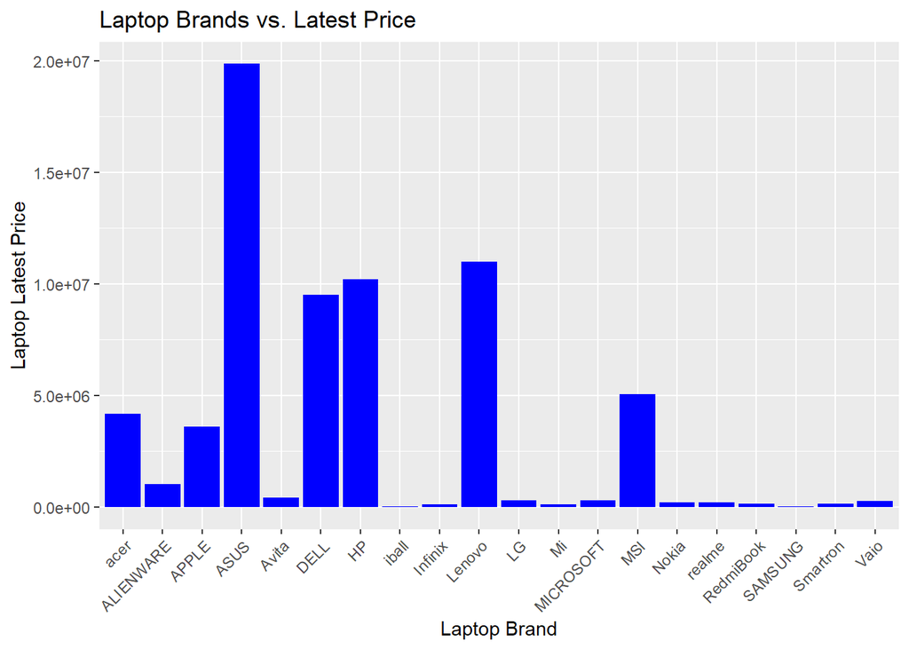

```r
p <- ggplot(data, aes(x = `brand`, y = `latest_price`)) +
  geom_bar(stat = "identity", fill = "blue") +
  labs(x = "Laptop Brand", y = "Laptop Latest Price") +
  ggtitle("Laptop Brands vs. Latest Price") +
  theme(axis.text.x = element_text(angle = 45, hjust = 1))

# Display the plot
print(p)
```

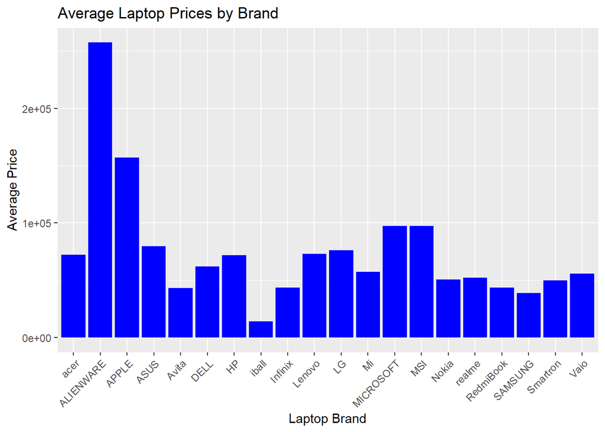

```r
avg_prices <- aggregate(latest_price ~ brand, data = data, FUN = mean)
colnames(avg_prices) <- c("brand", "Average Price")

p <- ggplot(avg_prices, aes(x = `brand`, y = `Average Price`)) +
  geom_bar(stat = "identity", fill = "blue") +
  labs(x = "Laptop Brand", y = "Average Price") +
  ggtitle("Average Laptop Prices by Brand") +
  theme(axis.text.x = element_text(angle = 45, hjust = 1))

# Display the plot
print(p)
```

Above graph will show us brands with their average price in rupees.

Questions for the next stage:

1. Is the average price of the products equal to the reference value of Rs. 73k?
2. Is the average star rating of the products equal to the reference value of 3.2?

```r
 # Subset data
touchscreen <- subset(data, Touchscreen=="Yes")
non_touchscreen <- subset(data, Touchscreen=="No")

# Compare means
t.test(touchscreen$latest_price, non_touchscreen$latest_price)
```

```
##
##  Welch Two Sample t-test
##
## data:  touchscreen$latest_price and non_touchscreen$latest_price
## t = 5.7177, df = 137.82, p-value = 6.423e-08
## alternative hypothesis: true difference in means is not equal to 0
## 95 percent confidence interval:
##  16461.94 33867.12
## sample estimates:
## mean of x mean of y
##  98506.54  73342.01
```

```r
# p-value < 0.05, reject H0
# Touchscreen laptops have higher average price
```

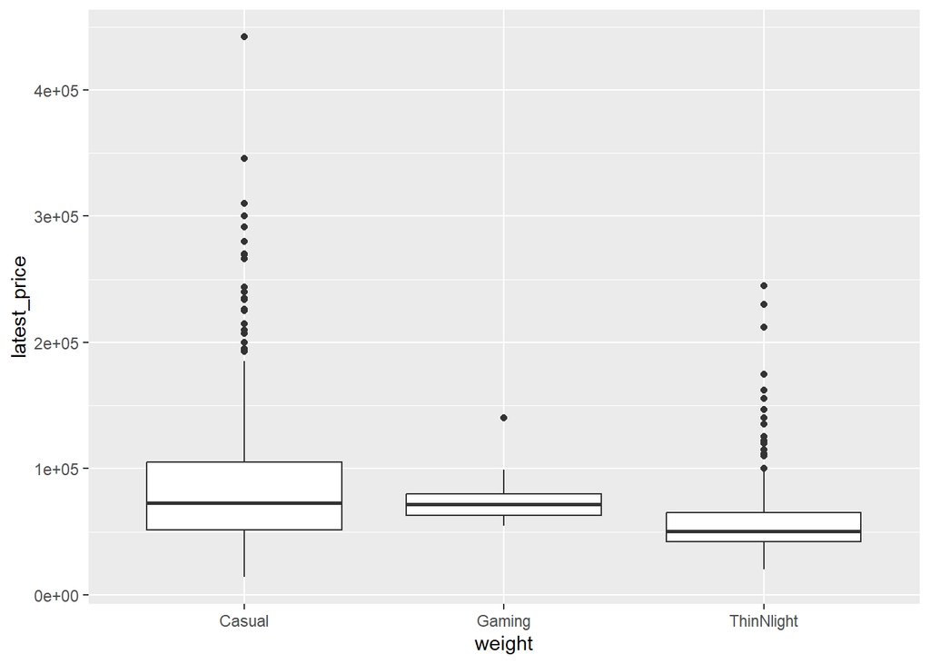

```r
ggplot(data, aes(x=weight, y=latest_price)) + geom_boxplot()
```

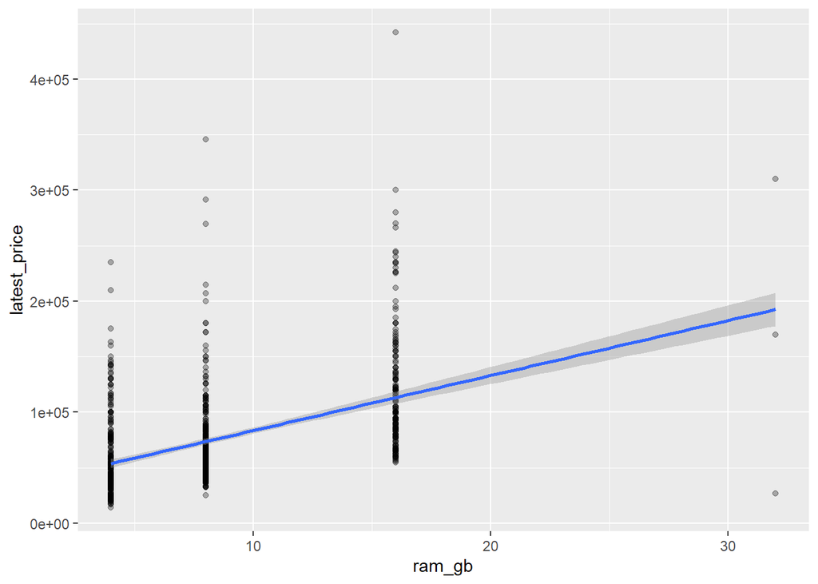

```r
ggplot(data, aes(ram_gb, latest_price)) +
  geom_point(alpha = 0.3) +
  geom_smooth(method="lm")
```

Trend 2: Higher RAM is strongly associated with a higher price

The linear trend shows a positive correlation between RAM capacity and price.